# 2501975684_FinalExam

2501975684_Arvio Anandi

2022-07-15

Link Video: https://drive.google.com/file/d/1ueQYvtKdnfnxbJr-5ptv8U89bDjBGf-z/view?usp=sharing

# The purpose of this logistic regression is to predict patient’s chance of getting a stroke contingent to the independent variables conditioned.

```r
library(ROCR)
```

```r
library(rpart)
library(rpart.plot)
library(dplyr)
library(ggplot2)
library(ggthemes)
data <- read.csv("StrokeData.csv")
```

**EXPLANATION**  
Loading packages and datasets.

```r
head(data)
```

```
##      id gender age hypertension heart_disease ever_married     work_type
## 1  9046   Male  67            0             1          Yes       Private
## 2 51676 Female  61            0             0          Yes Self-employed
## 3 31112   Male  80            0             1          Yes       Private
## 4 60182 Female  49            0             0          Yes       Private
## 5  1665 Female  79            1             0          Yes Self-employed
## 6 56669   Male  81            0             0          Yes       Private
##   Residence_type avg_glucose_level  bmi  smoking_status stroke
## 1          Urban            228.69 36.6 formerly smoked      1
## 2          Rural            202.21  N/A    never smoked      1
## 3          Rural            105.92 32.5    never smoked      1
## 4          Urban            171.23 34.4          smokes      1
## 5          Rural            174.12   24    never smoked      1
## 6          Urban            186.21   29 formerly smoked      1
```

**EXPLANATION**  
Table shows head of the dataset.

```r
dim(data)
```

```
## [1] 5110   12
```

**EXPLANATION**  
There is a total number of 5110 records and 12 features.

```r
str(data)
```

```
## 'data.frame':    5110 obs. of  12 variables:
##  $ id               : int  9046 51676 31112 60182 1665 56669 53882 10434 27419 60491 ...
##  $ gender           : chr  "Male" "Female" "Male" "Female" ...
##  $ age              : num  67 61 80 49 79 81 74 69 59 78 ...
##  $ hypertension     : int  0 0 0 0 1 0 1 0 0 0 ...
##  $ heart_disease    : int  1 0 1 0 0 0 1 0 0 0 ...
##  $ ever_married     : chr  "Yes" "Yes" "Yes" "Yes" ...
##  $ work_type        : chr  "Private" "Self-employed" "Private" "Private" ...
##  $ Residence_type   : chr  "Urban" "Rural" "Rural" "Urban" ...
##  $ avg_glucose_level: num  229 202 106 171 174 ...
##  $ bmi              : chr  "36.6" "N/A" "32.5" "34.4" ...
##  $ smoking_status   : chr  "formerly smoked" "never smoked" "never smoked" "smokes" ...
##  $ stroke           : int  1 1 1 1 1 1 1 1 1 1 ...
```

**EXPLANATION**  
Features Information  
1.) id (integer): unique identifier  
2.) gender (character): “Male”, “Female” or “Other”  
3) age (numeric): age of the patient  
4) hypertension (integer): 0 if the patient doesn’t have hypertension, 1 if the patient has hypertension  
5) heart_disease (integer): 0 if the patient doesn’t have any heart diseases, 1 if the patient has a heart disease  
6) ever_married (character): “No” or “Yes”  
7) work_type (character): “children”, “Govt_jov”, “Never_worked”, “Private” or “Self-employed”  
8) Residence_type (character): “Rural” or “Urban”  
9) avg_glucose_level (numeric): average glucose level in blood  
10) bmi (character): body mass index  
11) smoking_status (character): “formerly smoked”, “never smoked”, “smokes” or “Unknown”  
12) stroke (integer): 1 if the patient had a stroke or 0 if not  
*Note: “Unknown” in smoking_status means that the information is unavailable for this patient

```r
length(data[data=="?"])
```

```
## [1] 0
```

**EXPLANATION**  
There are no levels with the label “?” in this dataset.

```r
data$gender <- as.factor(data$gender)
data$ever_married <- as.factor(data$ever_married)
data$work_type <- as.factor(data$work_type)
data$Residence_type <- as.factor(data$Residence_type)
data$bmi <- as.numeric(data$bmi)
data$smoking_status <- as.factor(data$smoking_status)
data$stroke <- as.factor(data$stroke)
data$heart_disease <- as.factor(data$heart_disease)
data$hypertension <- as.factor(data$hypertension)
str(data)
```

```
## 'data.frame':    5110 obs. of  12 variables:
##  $ id               : int  9046 51676 31112 60182 1665 56669 53882 10434 27419 60491 ...
##  $ gender           : Factor w/ 3 levels "Female","Male",..: 2 1 2 1 1 2 2 1 1 1 ...
##  $ age              : num  67 61 80 49 79 81 74 69 59 78 ...
##  $ hypertension     : Factor w/ 2 levels "0","1": 1 1 1 1 2 1 2 1 1 1 ...
##  $ heart_disease    : Factor w/ 2 levels "0","1": 2 1 2 1 1 1 2 1 1 1 ...
##  $ ever_married     : Factor w/ 2 levels "No","Yes": 2 2 2 2 2 2 2 1 2 2 ...
##  $ work_type        : Factor w/ 5 levels "children","Govt_job",..: 4 5 4 4 5 4 4 4 4 4 ...
##  $ Residence_type   : Factor w/ 2 levels "Rural","Urban": 2 1 1 2 1 2 1 2 1 2 ...
##  $ avg_glucose_level: num  229 202 106 171 174 ...
##  $ bmi              : num  36.6 NA 32.5 34.4 24 29 27.4 22.8 NA 24.2 ...
##  $ smoking_status   : Factor w/ 4 levels "formerly smoked",..: 1 2 2 3 2 1 2 2 4 4 ...
##  $ stroke           : Factor w/ 2 levels "0","1": 2 2 2 2 2 2 2 2 2 2 ...
```

**EXPLANATION**  
We convert data types according to each of its types. e.g gender from character to factor.

```r
sapply(data, function(x) sum(is.na(x)))
```

```
##                id            gender               age      hypertension
##                 0                 0                 0                 0
##     heart_disease      ever_married         work_type    Residence_type
##                 0                 0                 0                 0
## avg_glucose_level               bmi    smoking_status            stroke
##                 0               201                 0                 0
```

**EXPLANATION**  
- Only BMI feature has missing values  
- BMI has 201 records with missing values

# Checking for assumptions

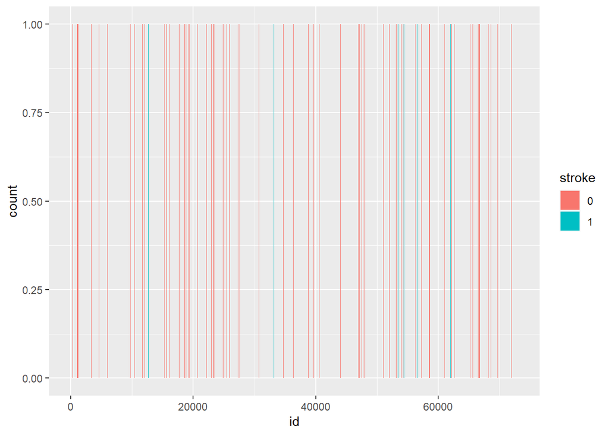

```r
t <- ggplot(data, aes(id,fill = stroke))
t <- t + geom_histogram(stat="count")
print(t)
```

**EXPLANATION**  
Since there is too much unique values which are random and it shows that id and stroke have no correlation in real life, then it is better to remove id as independent variable.

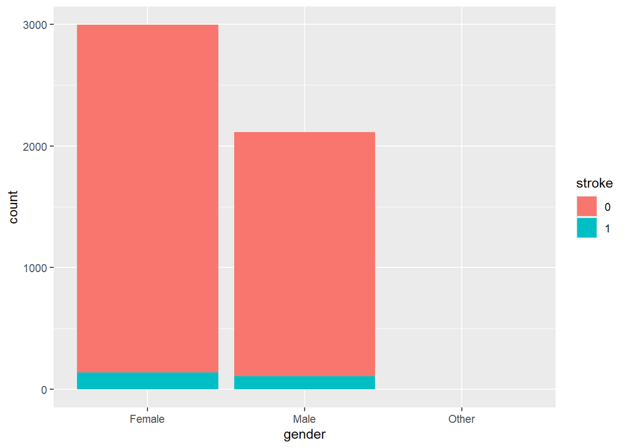

```r
t <- ggplot(data, aes(gender,fill = stroke))
t <- t + geom_histogram(stat="count")
print(t)
```

**EXPLANATION**  
Gender characteristic doesn’t have so much significance.

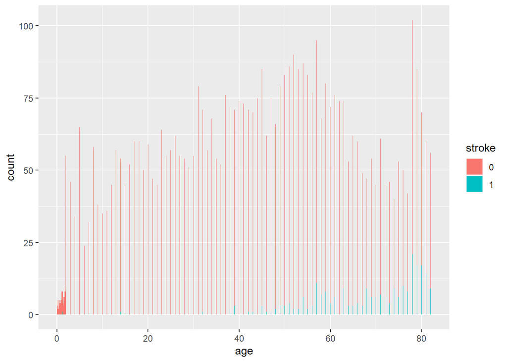

```r
t <- ggplot(data, aes(age,fill = stroke))
t <- t + geom_histogram(stat="count")
print(t)
```

**EXPLANATION**  
We can say that people of age > 40 is prone to having stroke.

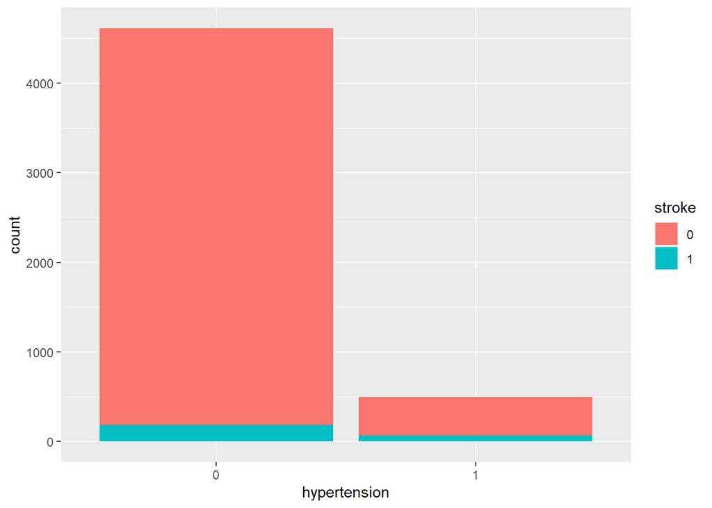

```r
t <- ggplot(data, aes(hypertension,fill = stroke))
t <- t + geom_histogram(stat="count")
print(t)
```

**EXPLANATION**  
It seems that hypertension has an effect on chance of getting stroke within a small proportion.

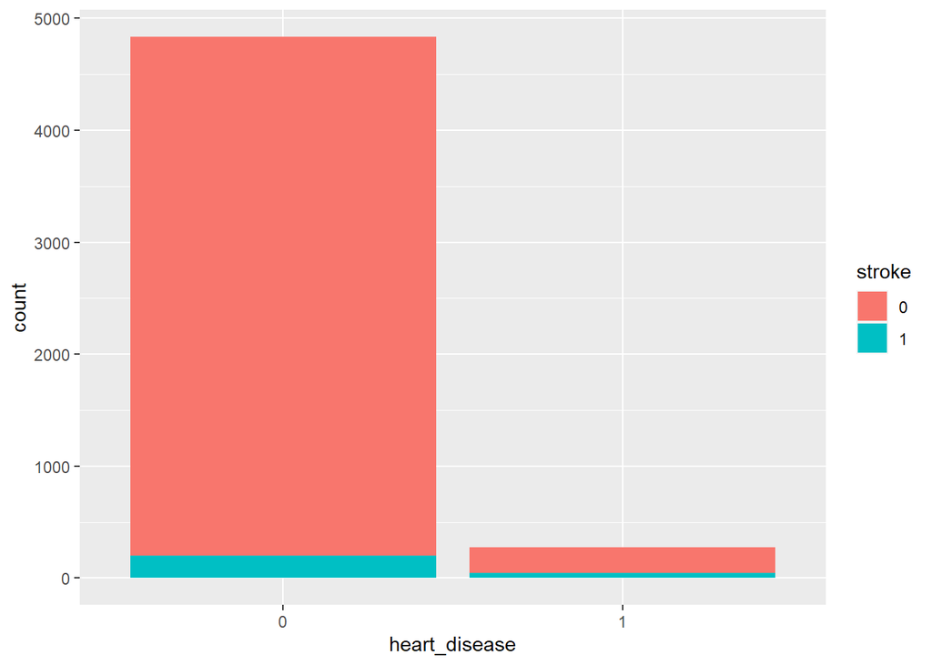

```r
t <- ggplot(data, aes(heart_disease,fill = stroke))
t <- t + geom_histogram(stat="count")
print(t)
```

**EXPLANATION**  
1. People with heart disease have more tendencies of having a stroke.  
2. People with no heart disease have less tendencies of having a stroke.

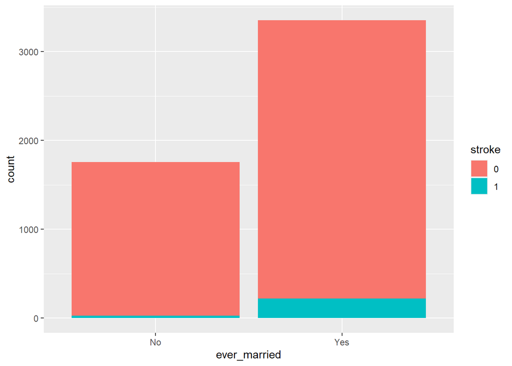

```r
t <- ggplot(data, aes(ever_married,fill = stroke))
t <- t + geom_histogram(stat="count")
print(t)
```

**EXPLANATION**  
People who ever married have more probability to have stroke compared to people who never married.

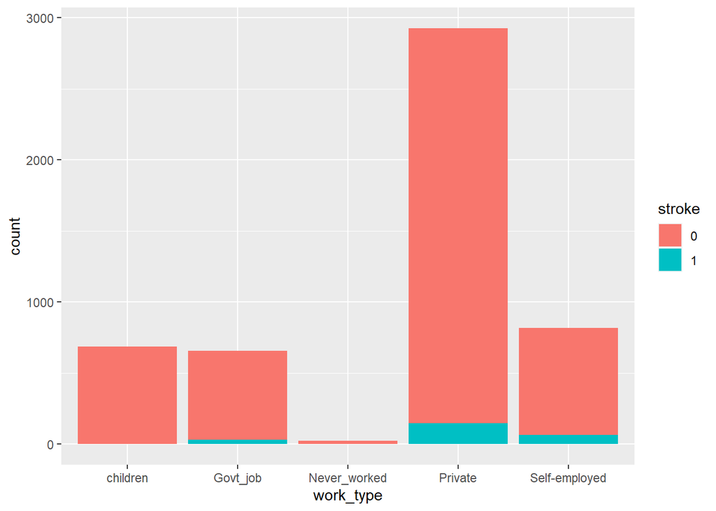

```r
t <- ggplot(data, aes(work_type,fill = stroke))
t <- t + geom_histogram(stat="count")
print(t)
```

**EXPLANATION**

1. People with self-employed jobs have the most probability of getting a stroke from all the work types.
2. Children have the least probability of getting a stroke.

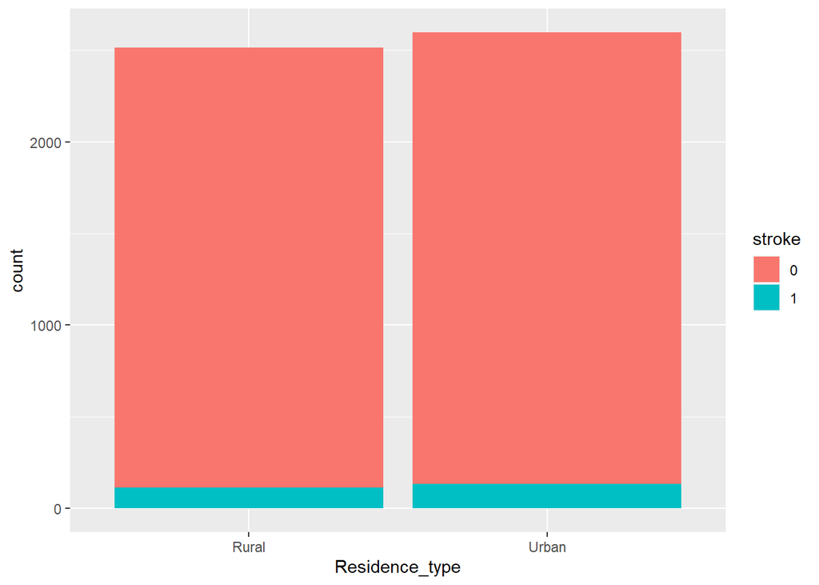

```r
t <- ggplot(data, aes(Residence_type,fill = stroke))
t <- t + geom_histogram(stat="count")
print(t)
```

**EXPLANATION**  
There isn’t anything important to interpret from residence type.

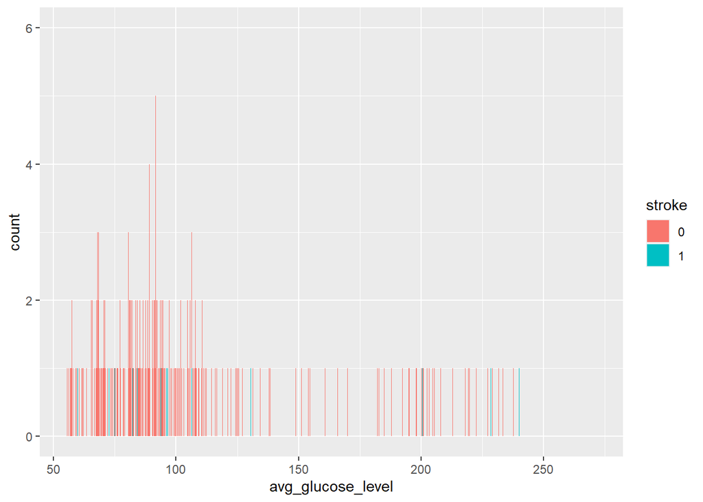

```r
t <- ggplot(data, aes(avg_glucose_level,fill = stroke))
t <- t + geom_histogram(stat="count")
print(t)
```

**EXPLANATION**  
Average glucose level distribution is random.

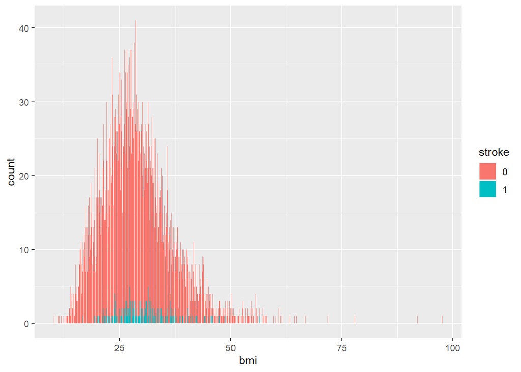

```r
t <- ggplot(data, aes(bmi,fill = stroke))
t <- t + geom_histogram(stat="count")
print(t)
```

**EXPLANATION**  
People ranging within 15 to 50 of BMI tend to have stroke compared to other intervals.

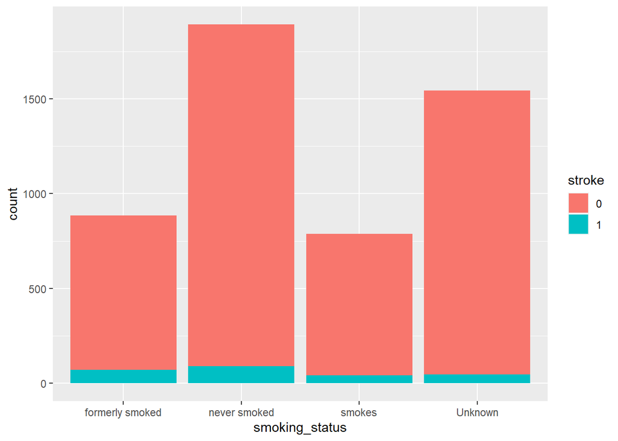

```r
t <- ggplot(data, aes(smoking_status,fill = stroke))
t <- t + geom_histogram(stat="count")
print(t)
```

```r
sapply(data, function(x) length(unique(x)))
```

```
##                id            gender               age      hypertension
##              5110                 3               104                 2
##     heart_disease      ever_married         work_type    Residence_type
##                 2                 2                 5                 2
## avg_glucose_level               bmi    smoking_status            stroke
##              3979               419                 4                 2
```

**EXPLANATION**  
We can deduct:  
- Feature Id should be removed because there is no correlation between the label with probability of having a stroke.  
- We can fit the rest of the features to our model.

## Data preparation

```r
data$id <- NULL
sapply(data, function(x) sum(is.na(x)))
```

```
##            gender               age      hypertension     heart_disease
##                 0                 0                 0                 0
##      ever_married         work_type    Residence_type avg_glucose_level
##                 0                 0                 0                 0
##               bmi    smoking_status            stroke
##               201                 0                 0
```

**EXPLANATION**  
We remove id variable from the dataset as it is not needed.

```r
data$bmi[is.na(data$bmi)] <- mean(data$bmi, na.rm=T)
sapply(data, function(x) sum(is.na(x)))
```

```
##            gender               age      hypertension     heart_disease
##                 0                 0                 0                 0
##      ever_married         work_type    Residence_type avg_glucose_level
##                 0                 0                 0                 0
##               bmi    smoking_status            stroke
##                 0                 0                 0
```

**EXPLANATION**  
We handle the missing values for bmi feature by changing it to mean of the feature.

# Verifying imbalances in dataset

```r
xtabs(~ stroke + gender, data=data)
```

```
##       gender
## stroke Female Male Other
##      0   2853 2007     1
##      1    141  108     0
```

```r
xtabs(~ stroke + age , data=data)
```

```
##       age
## stroke 0.08 0.16 0.24 0.32 0.4 0.48 0.56 0.64 0.72 0.8 0.88  1 1.08 1.16 1.24
##      0    2    3    5    5   2    3    5    4    5   4    5  5    8    4    8
##      1    0    0    0    0   0    0    0    0    0   0    0  0    0    0    0
##       age
## stroke 1.32 1.4 1.48 1.56 1.64 1.72 1.8 1.88  2  3  4  5  6  7  8  9 10 11 12
##      0    7   3    6    4    8    6   9    8 55 46 34 65 24 32 58 38 35 36 45
##      1    1   0    0    0    0    0   0    0  0  0  0  0  0  0  0  0  0  0  0
##       age
## stroke 13 14 15 16 17 18 19 20 21 22 23 24 25 26 27 28 29 30 31 32 33 34 35 36
##      0 57 53 45 52 60 60 50 59 47 45 64 55 57 62 55 54 51 55 79 70 57 68 54 52
##      1  0  1  0  0  0  0  0  0  0  0  0  0  0  0  0  0  0  0  0  1  0  0  0  0
##       age
## stroke 37 38 39 40 41 42 43 44 45 46 47 48 49 50 51 52 53 54 55 56 57 58 59 60
##      0 76 70 68 74 73 70 69 75 82 61 74 64 76 80 82 88 83 81 81 74 84 61 72 68
##      1  0  2  3  0  0  1  1  0  3  1  1  2  3  3  4  2  2  6  2  3 11  7  8  4
##       age
## stroke 61 62 63 64 65 66 67 68 69 70 71 72 73 74 75 76 77 78 79 80 81 82
##      0 70 74 65 50 59 56 46 38 48 39 54 39 42 31 47 40 34 81 68 53 46 47
##      1  6  0  9  3  3  4  3  9  6  6  7  6  4  9  6 10  8 21 17 17 14  9
```

```r
xtabs(~ stroke + hypertension, data=data)
```

```
##       hypertension
## stroke    0    1
##      0 4429  432
##      1  183   66
```

```r
xtabs(~ stroke +  heart_disease, data=data)
```

```
##       heart_disease
## stroke    0    1
##      0 4632  229
##      1  202   47
```

```r
xtabs(~ stroke +  ever_married, data=data)
```

```
##       ever_married
## stroke   No  Yes
##      0 1728 3133
##      1   29  220
```

```r
xtabs(~ stroke +  work_type, data=data)
```

```
##       work_type
## stroke children Govt_job Never_worked Private Self-employed
##      0      685      624           22    2776           754
##      1        2       33            0     149            65
```

```r
xtabs(~ stroke +  Residence_type, data=data)
```

```
##       Residence_type
## stroke Rural Urban
##      0  2400  2461
##      1   114   135
```

```r
xtabs(~ stroke +  avg_glucose_level, data=data)
```

[output not shown]

[output cut: 1385 more lines]

[output not shown]

```r
xtabs(~ stroke +  smoking_status, data=data)
```

```
##       smoking_status
## stroke formerly smoked never smoked smokes Unknown
##      0             815         1802    747    1497
##      1              70           90     42      47
```

# Splitting data to train and validation sets

```r
sample = floor(0.8*nrow(data))

set.seed(800)
rand = sample(seq_len(nrow(data)),size = sample)
train = data[rand,]
validation = data[-rand,]
```

**EXPLANATION**  
We split the training set to accomodate 80% of the data, while the validation set accomodating 20%.

## Logistic Regression

```r
logistics <- glm(stroke ~ .,family = binomial(link = "logit"), data = train)
summary(logistics)
```

```
##
## Call:
## glm(formula = stroke ~ ., family = binomial(link = "logit"),
##     data = train)
##
## Deviance Residuals:
##     Min       1Q   Median       3Q      Max
## -1.2073  -0.3160  -0.1643  -0.0839   3.7076
##
## Coefficients:
##                              Estimate Std. Error z value Pr(>|z|)
## (Intercept)                -7.194e+00  1.074e+00  -6.698 2.11e-11 ***
## genderMale                  7.850e-02  1.600e-01   0.491 0.623778
## genderOther                -1.069e+01  1.455e+03  -0.007 0.994138
## age                         7.273e-02  6.467e-03  11.247  < 2e-16 ***
## hypertension1               3.038e-01  1.873e-01   1.622 0.104765
## heart_disease1              4.191e-01  2.132e-01   1.966 0.049285 *
## ever_marriedYes            -2.771e-01  2.516e-01  -1.101 0.270737
## work_typeGovt_job          -4.941e-01  1.117e+00  -0.442 0.658252
## work_typeNever_worked      -9.887e+00  3.331e+02  -0.030 0.976323
## work_typePrivate           -3.066e-01  1.100e+00  -0.279 0.780484
## work_typeSelf-employed     -6.255e-01  1.119e+00  -0.559 0.576222
## Residence_typeUrban        -1.154e-02  1.557e-01  -0.074 0.940940
## avg_glucose_level           4.526e-03  1.339e-03   3.381 0.000723 ***
## bmi                         3.933e-03  1.302e-02   0.302 0.762569
## smoking_statusnever smoked -2.382e-01  1.988e-01  -1.198 0.230817
## smoking_statussmokes        1.505e-01  2.378e-01   0.633 0.526857
## smoking_statusUnknown      -1.945e-01  2.391e-01  -0.814 0.415873
## ---
## Signif. codes:  0 '***' 0.001 '**' 0.01 '*' 0.05 '.' 0.1 ' ' 1
##
## (Dispersion parameter for binomial family taken to be 1)
##
##     Null deviance: 1573.2  on 4087  degrees of freedom
## Residual deviance: 1246.2  on 4071  degrees of freedom
## AIC: 1280.2
##
## Number of Fisher Scoring iterations: 14
```

**EXPLANATION**  
From model 1, we can conduct:  
1.) It can be seen that the predictor variable age have a p-value < 0.0001. This means that these variables are highly statistically significant predictors in the model.  
2.) From subtracting the residual deviance to null deviance, we get the chi-square of 327 with df of 16, resulting with p-value of 0.0000. This tells us that the model is highly useful.  
3.) We move on with another model with age as a highly statistically significant predictor variable.

```r
logistics <- glm(stroke ~ age,family = binomial(link = "logit"), data = train)
summary(logistics)
```

```
##
## Call:
## glm(formula = stroke ~ age, family = binomial(link = "logit"),
##     data = train)
##
## Deviance Residuals:
##     Min       1Q   Median       3Q      Max
## -0.7442  -0.3236  -0.1771  -0.0830   3.7760
##
## Coefficients:
##              Estimate Std. Error z value Pr(>|z|)
## (Intercept) -7.226254   0.375767  -19.23   <2e-16 ***
## age          0.074193   0.005507   13.47   <2e-16 ***
## ---
## Signif. codes:  0 '***' 0.001 '**' 0.01 '*' 0.05 '.' 0.1 ' ' 1
##
## (Dispersion parameter for binomial family taken to be 1)
##
##     Null deviance: 1573.2  on 4087  degrees of freedom
## Residual deviance: 1279.4  on 4086  degrees of freedom
## AIC: 1283.4
##
## Number of Fisher Scoring iterations: 7
```

**EXPLANATION**  
From model 2, we can conduct:  
1.) The predictor variable age has a very high statistical significance with stroke variable.  
2.) With chi-square value of 293.8 with df of 1, we get p-value of 0.000000. This shows that the model is as useful as the first model.  
3.) The AIC shows slightly higher difference in value as compared to the first model, but this doesn’t matter as it fits as the best model.  
4.) We will proceed with building a model of this regression.

[figure not shown]

```r
predicted.data <- data.frame(prob = data$stroke, age = data$age, fit = predict(logistics,data))
predicted.data$fit_prob <- 1+ exp(predicted.data$fit+1.4)/(1+exp(predicted.data$fit))
ggplot(data=predicted.data, aes(x=age,y=prob))+
  geom_point(aes(color=age),alpha=1,shape=1,stroke=2)+
  geom_line(aes(x=age,y=fit_prob))
```

**EXPLANATION**  
1.) Most of the people with stroke cumulates between the age 40 - 80. 2,) People without stroke ranges from age 0 - 80. 3.) The prediction curve predicts people without stroke having low probability of getting a stroke. 4.) The prediction curve tends to have many residuals when predicting people with stroke of having a high probability of getting a stroke.

# Evaluation

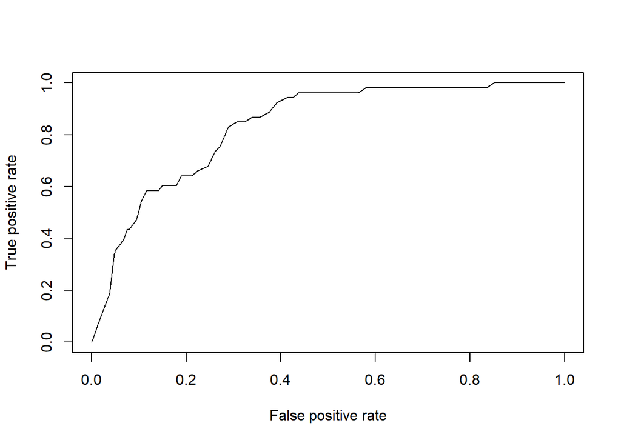

```r
prob <- predict(logistics, newdata=subset(validation, select = c(1,2,3,4,5,6,7,8,9,10)), type="response")
prdt <- prediction(prob, validation$stroke)
rocCurve <- performance(prdt, measure = "tpr", x.measure = "fpr")
plot(rocCurve)
```

**EXPLANATION**  
The ROC Curve line curves closer to the top-left. This indicates that the model does a good job classifying between the two categories which comprise to the target variable ‘stroke’. This also means the model’s performance is good and accurate. Therefore, we can proceed to the next steps.

```r
auc <- performance(prdt, measure = "auc")
auc <- auc@y.values[[1]]
auc
```

```
## [1] 0.8346574
```

**EXPLANATION**  
The Area Under the Curve value is > 0.8, thus indicating a good performance model.

# Accuracy testing

```r
result <- ifelse(prob > 0.5, 1, 0)
mError <- mean(result != validation$stroke)
print(paste("Accuracy : ", 1-mError))
```

```
## [1] "Accuracy :  0.948140900195695"
```

**EXPLANATION**  
The accuracy of the model is high with a value 0.94 closing to 1.